# Predicting Next Word Application

20 de Dezembro de 2018

## Suggesting Next Word Web Application

Using text mining techniques it was developed a web application to suggest the next word after inserting words by the user. The next word is predicted based on an sample (15%) of the English part of SwiftKey data (https://d396qusza40orc.cloudfront.net/dsscapstone/dataset/Coursera-SwiftKey.zip).

This presentation will show you how the web application works and the structure / algorithm that is applied.

Any question, please contact Silverio Neves (silveriomsn@gmail.com). The project was developped for the Capstone Project (Data Science Specialization - Coursera course - John Hoptins University)

## How to use the web application (part I)

The user has an input text section on the left side to insert a text.

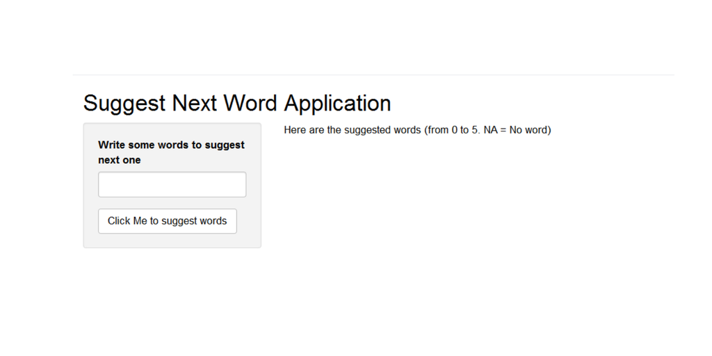

## How to use the web application (part II)

After inserting the text the user can click on the button bellow the text to perform the algorithm and show the suggested words.

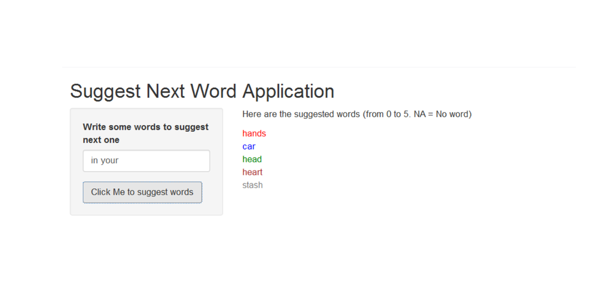

## How the prediction algorithm was buitlt

From the blogs, twitter and news data was construct a single database for 4-gram, 3-gram and 2-gram.

If input text has 4 or more words - Capture the last 3 words and check in four 4-gram with the first 3 words. If there is no results it will use only the last 2 words of the input text and check with the second and third in the 4-gram.

- With no results the algorithm will use the last 2 words of the input text to check in the 3-gram data base. if no results will use the last word of the input text to check in the 3-gram and 2-gram if necessary.

## Conclusions

Becasue of performance issues, it was built the n-gram database using only 15% of the original data. To have better results it is recommended to includ more data, but it is a tradeoff between performance (time) and accuracy.